# Модели со смешанными эффектами. Практикум

Что если по штатам различается эффект партийной принадлежности? Проверим аналогичной спецификацией, добавив случайный эффект на party.

```r
model4.2 <- lmer(votepct ~ party + (1 + party|state_id), REML = FALSE, data = ME)
summary(model4.2)
```

```
## Linear mixed model fit by maximum likelihood . t-tests use Satterthwaite's
##   method [lmerModLmerTest]
## Formula: votepct ~ party + (1 + party | state_id)
##    Data: ME
##
##      AIC      BIC   logLik deviance df.resid
##   -242.4   -216.8    127.2   -254.4      521
##
## Scaled residuals:
##     Min      1Q  Median      3Q     Max
## -3.7731 -0.5559  0.0134  0.5491  4.7581
##
## Random effects:
##  Groups   Name        Variance Std.Dev. Corr
##  state_id (Intercept) 0.02714  0.1647
##           party       0.01063  0.1031   -0.88
##  Residual             0.03021  0.1738
## Number of obs: 527, groups:  state_id, 50
##
## Fixed effects:
##             Estimate Std. Error       df t value             Pr(>|t|)
## (Intercept)  0.25694    0.02800 40.00208   9.177      0.0000000000216 ***
## party        0.51259    0.02386 36.35950  21.483 < 0.0000000000000002 ***
## ---
## Signif. codes:  0 '***' 0.001 '**' 0.01 '*' 0.05 '.' 0.1 ' ' 1
##
## Correlation of Fixed Effects:
##       (Intr)
## party -0.790
```

И модель с полным набором исходных предикторов:

```r
model4.2.1 <- lmer(votepct ~ money + acres + party + (1 + party|state_id), REML = FALSE, data = ME)
summary(model4.2.1)
```

```
## Linear mixed model fit by maximum likelihood . t-tests use Satterthwaite's
##   method [lmerModLmerTest]
## Formula: votepct ~ money + acres + party + (1 + party | state_id)
##    Data: ME
##
##      AIC      BIC   logLik deviance df.resid
##   -312.0   -277.8    164.0   -328.0      519
##
## Scaled residuals:
##     Min      1Q  Median      3Q     Max
## -3.7460 -0.5764 -0.0002  0.5632  4.5800
##
## Random effects:
##  Groups   Name        Variance Std.Dev. Corr
##  state_id (Intercept) 0.010816 0.10400
##           party       0.008485 0.09211  -0.73
##  Residual             0.027284 0.16518
## Number of obs: 527, groups:  state_id, 50
##
## Fixed effects:
##                Estimate  Std. Error          df t value             Pr(>|t|)
## (Intercept)   0.2047760   0.0209332  34.7334789   9.782  0.00000000001630022
## money         0.0040650   0.0004947 510.9469193   8.217  0.00000000000000173
## acres         0.0005924   0.0003174  36.9971747   1.866               0.0699
## party         0.4882487   0.0222164  37.8990776  21.977 < 0.0000000000000002
##
## (Intercept) ***
## money       ***
## acres       .
## party       ***
## ---
## Signif. codes:  0 '***' 0.001 '**' 0.01 '*' 0.05 '.' 0.1 ' ' 1
##
## Correlation of Fixed Effects:
##       (Intr) money  acres
## money -0.164
## acres -0.142 -0.325
## party -0.669 -0.137 -0.001
```

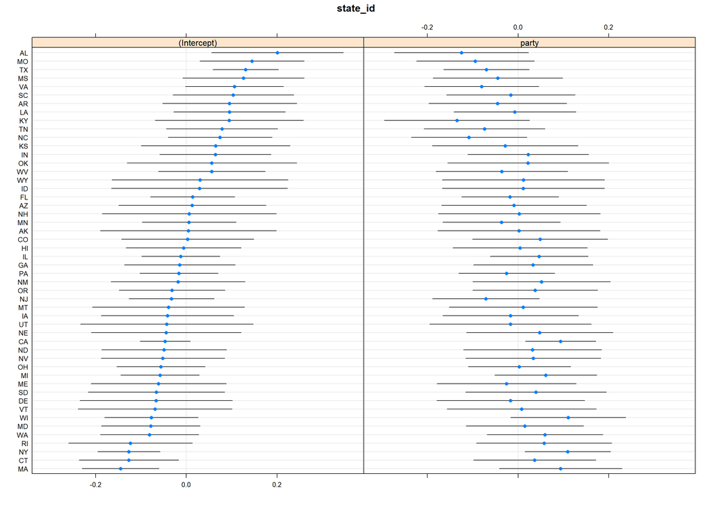

```r
dotplot(ranef(model4.2.1, condVar=TRUE))
```

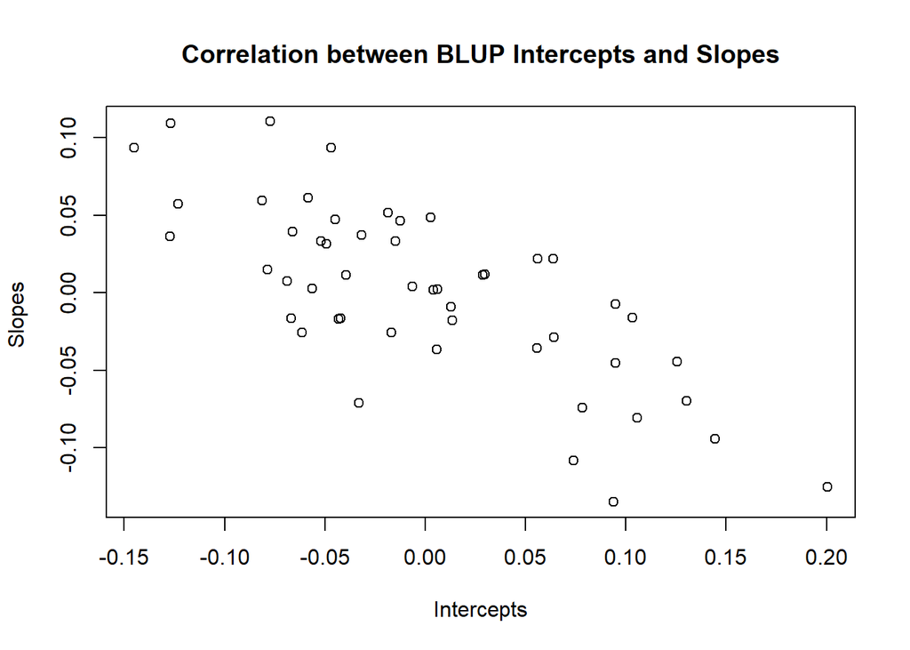

```r
random4.2.1 <- ranef(model4.2.1)
unique <- cbind((random4.2.1$state_id[,1]),(random4.2.1$state_id[,2]))
plot(unique,
     xlab = 'Intercepts', ylab = "Slopes ",
     main = "Correlation between BLUP Intercepts and Slopes")
```

```r
model_nlme_1 <- lme(votepct ~  money + party + acres, random = list(state_id = pdDiag(~1 + ~party)), method = "ML", data = ME)
summary(model_nlme_1)
```

```
## Linear mixed-effects model fit by maximum likelihood
##   Data: ME
##         AIC       BIC   logLik
##   -307.9102 -278.0398 160.9551
##
## Random effects:
##  Formula: ~1 + ~party | state_id
##  Structure: Diagonal
##         (Intercept)      party  Residual
## StdDev:  0.07850753 0.06907026 0.1661866
##
## Fixed effects:  votepct ~ money + party + acres
##                 Value   Std.Error  DF   t-value p-value
## (Intercept) 0.1934876 0.017789906 475 10.876257  0.0000
## money       0.0041458 0.000497678 475  8.330253  0.0000
## party       0.4858930 0.019899316 475 24.417574  0.0000
## acres       0.0009781 0.000365842  48  2.673609  0.0102
##  Correlation:
##       (Intr) money  party
## money -0.185
## party -0.382 -0.153
## acres -0.204 -0.298 -0.006
##
## Standardized Within-Group Residuals:
##          Min           Q1          Med           Q3          Max
## -3.706280444 -0.602561498 -0.003090901  0.538173214  4.481036555
##
## Number of Observations: 527
## Number of Groups: 50
```

Несмотря на то, что модель со смешанными эффектами в явном виде учитывает специфику единиц анализа на втором уровне (в нашем случае – штатов), это не избавляет нас от необходимости выявления влиятельных наблюдений. По графику ниже на основании меры Кука видно, что такими влиятельными наблюдениями для модели 4.2 являются штаты Кентукки, Нью-Джерси и Калифорния.

```r
inf <- influence(model4.2, group = "state_id", data = ME)
cooks.distance.estex(inf, sort=TRUE)
```

```
##             [,1]
## AK 0.00004054182
## NH 0.00017916274
## AZ 0.00075076707
## HI 0.00084344245
## MN 0.00104960260
## WV 0.00187762982
## KS 0.00221803193
## NE 0.00263385176
## MT 0.00272537048
## ND 0.00344670156
## PA 0.00418566106
## FL 0.00453735574
## AR 0.00455857983
## NV 0.00456286730
## ID 0.00518232184
## OH 0.00519854919
## OR 0.00616596050
## WY 0.00791596535
## MI 0.00839486907
## SD 0.00841956199
## IA 0.00889327204
## WA 0.01177476240
## NM 0.01235928103
## TX 0.01254590812
## OK 0.01283935538
## MS 0.01516498980
## CO 0.02028902789
## IN 0.02223470186
## MA 0.02245247585
## LA 0.02251916324
## MD 0.02253094147
## VT 0.02463733979
## MO 0.02611022862
## RI 0.02679411108
## NY 0.02710795542
## SC 0.02892248805
## VA 0.02923190794
## DE 0.03121342084
## GA 0.03553045880
## WI 0.03696959394
## UT 0.03831808836
## IL 0.04387885446
## CT 0.05006207459
## ME 0.06476927772
## TN 0.07166585615
## AL 0.07237961159
## NC 0.07920816415
## KY 0.08540665468
## CA 0.09817495570
## NJ 0.30782079613
```

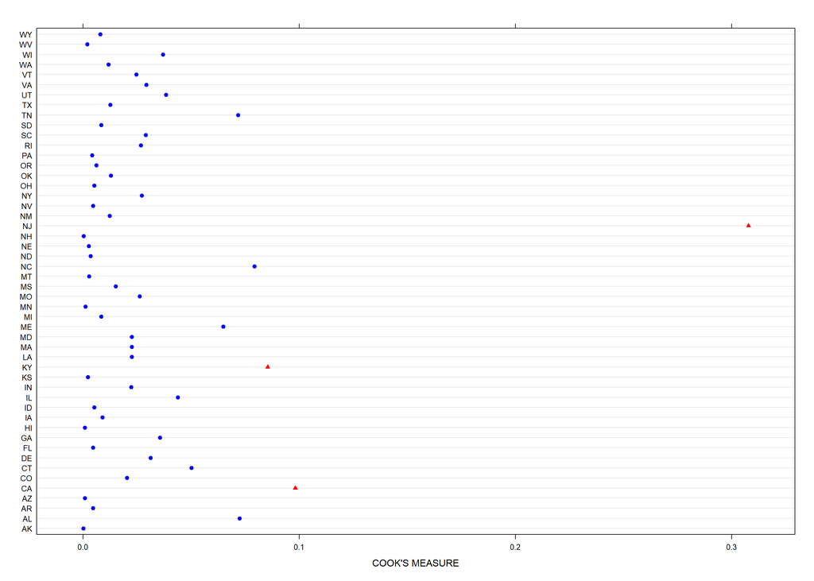

```r
plot(inf, which = "cook", xlab = "COOK'S MEASURE", cutoff = 4/length(state_unique))
```

Проверим также, можно ли считать распределение остатков на первом уровне и случайных эффектов близким к нормальному (одно из допущений ME-модели). Для этого изобразим графики в формате QQ-plot (сравнение квантилей эмпирического и теоретического нормального распределения) и наложения графиков функций плотности друг на друга для остатков первого уровня (на уровне членов Конгресса), эти графики показывают, что наиболее значимые отклонения предсказуемо по хвостам распределения. В частности, в рамках домашнего задания Вам предстоит подумать, как можно больше приблизить распределение к нормальному.

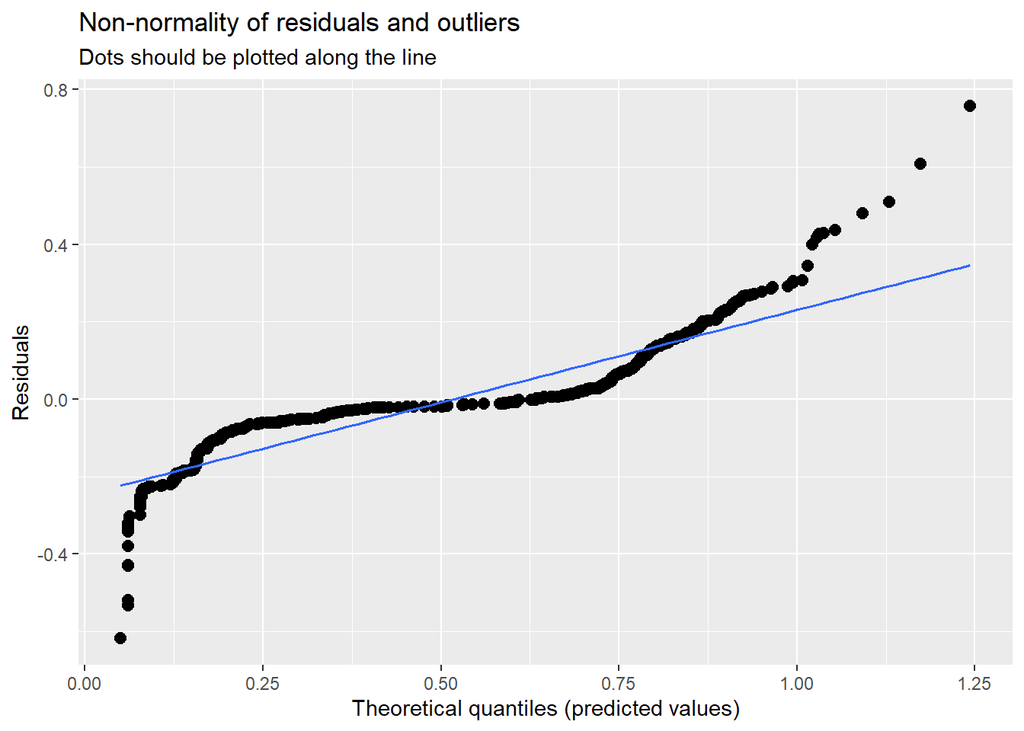

```r
plot_model(model4.2.1, type = "diag")[1]
```

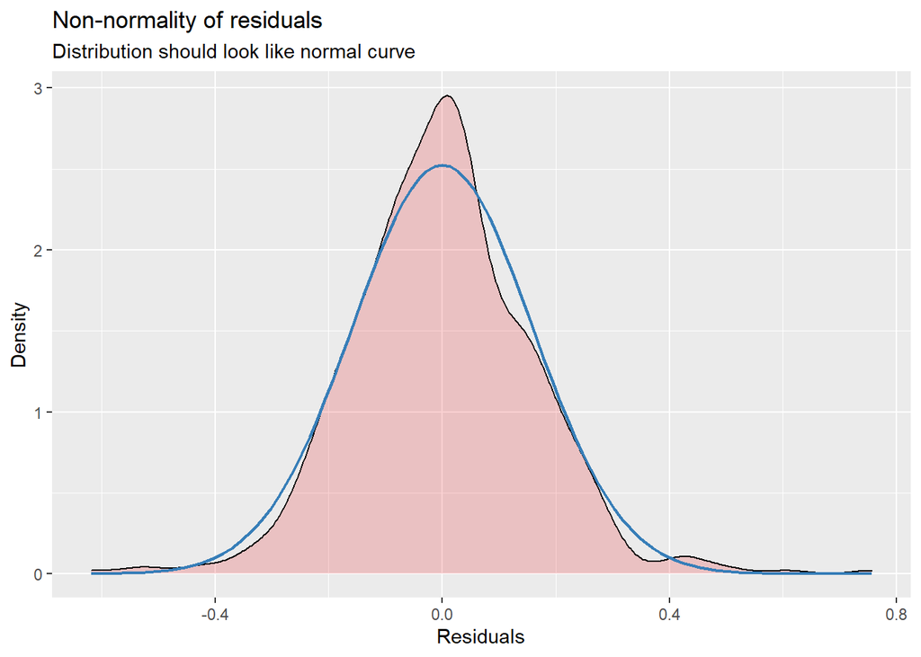

```r
plot_model(model4.2.1, type = "diag")[3]
```

На следующем графике посмотрим на распределение для случайных эффектов. В целом приближение к нормальному достаточно хорошее.

```
## [[1]]
## [[1]]$state_id
```

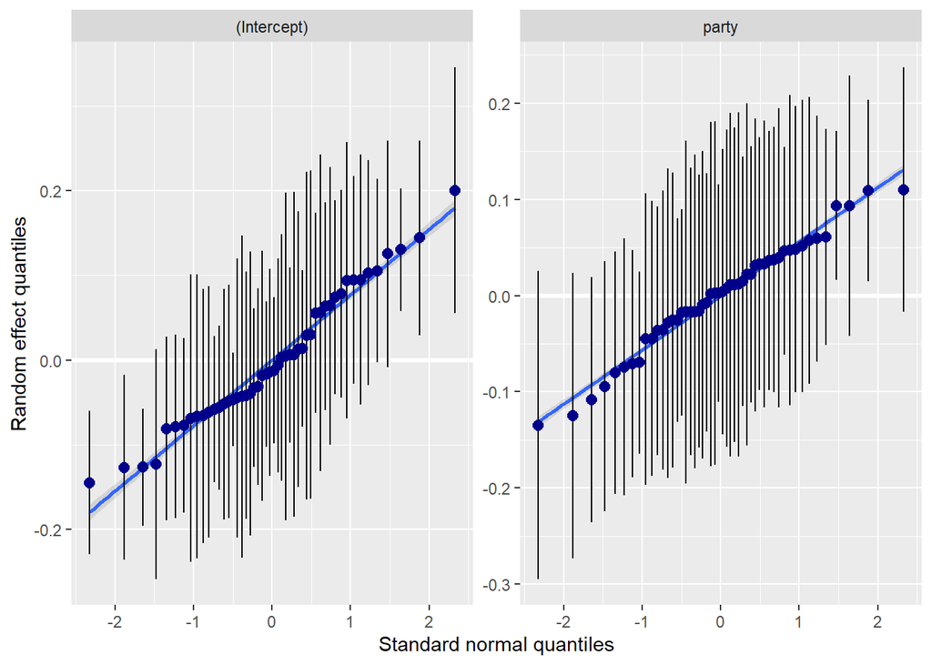

```r
plot_model(model4.2.1, type = "diag")[2]
```

**4. Добавляем cross-level interaction**

В соответствии с одной из гипотез авторов добавляем в модель переменную взаимодействия между характеристиками разных уровней – партийной принадлежности и площади табачных плантаций. Оценка коэффициента при данной переменной взаимодействия оказывается значимой, что говорит о том, что в штатах с большей площадью табачных плантаций эффект партийной принадлежности на долю голосов в поддержку табачной индустрии становится менее выраженным. Оценка коэффициента при acres теперь приобретает значимость, что неудивительно, так как теперь у этого коэффициента меняется интерпретация: в данном случае интерпретируем в терминах условного эффекта, а именно, эффекта для подвыборки представителей Демократической партии (party = 0).

```r
model5 <- lmer(votepct ~ money + party + acres + party*acres + (1 + party|state_id), REML = FALSE, data = ME)
summary(model5)
```

```
## Linear mixed model fit by maximum likelihood . t-tests use Satterthwaite's
##   method [lmerModLmerTest]
## Formula: votepct ~ money + party + acres + party * acres + (1 + party |
##     state_id)
##    Data: ME
##
##      AIC      BIC   logLik deviance df.resid
##   -322.8   -284.4    170.4   -340.8      518
##
## Scaled residuals:
##     Min      1Q  Median      3Q     Max
## -3.7296 -0.5834  0.0081  0.5848  4.5818
##
## Random effects:
##  Groups   Name        Variance Std.Dev. Corr
##  state_id (Intercept) 0.009137 0.09559
##           party       0.004629 0.06804  -0.71
##  Residual             0.027154 0.16479
## Number of obs: 527, groups:  state_id, 50
##
## Fixed effects:
##                Estimate  Std. Error          df t value             Pr(>|t|)
## (Intercept)   0.1859884   0.0202907  38.4145889   9.166  0.00000000003272077
## money         0.0040194   0.0004896 512.5065956   8.210  0.00000000000000181
## party         0.5164640   0.0209246  38.8941096  24.682 < 0.0000000000000002
## acres         0.0019306   0.0004851  60.0507199   3.980             0.000188
## party:acres  -0.0017391   0.0004644  55.5266832  -3.745             0.000431
##
## (Intercept) ***
## money       ***
## party       ***
## acres       ***
## party:acres ***
## ---
## Signif. codes:  0 '***' 0.001 '**' 0.01 '*' 0.05 '.' 0.1 ' ' 1
##
## Correlation of Fixed Effects:
##             (Intr) money  party  acres
## money       -0.156
## party       -0.662 -0.159
## acres       -0.272 -0.238  0.262
## party:acres  0.235  0.037 -0.336 -0.770
```

С одной стороны, такая модель отвечает задумке авторов. С другой стороны, не стоит забывать, что мы на предудущем шаге выявили, что вариация случайного эффекта для партийной принадлежности не так уж велика, поэтому включение дополнительного модератора, объясняющего различия во взаимосвязи, может быть сомнительным.